# Assignment 3

Adriana LH

9/21/2020

I am looking into internet access within the multiple census tracts of Suffolk County, MA. I am examining the relationship between internet access (percentage of people with internet in each tract), racial/ethnic makeup of each census tract, the total population of each census tract, nativity of residents of the tract, and the median age.

## Relationship #1: two continuous variables in three tests

```r
correlation1 <- cor.test(MA_tracts$med_ageE, MA_tracts$total_popE)

correlation1
```

```
##
##  Pearson's product-moment correlation
##
## data:  MA_tracts$med_ageE and MA_tracts$total_popE
## t = -1.1849, df = 195, p-value = 0.2375
## alternative hypothesis: true correlation is not equal to 0
## 95 percent confidence interval:
##  -0.22172349  0.05590808
## sample estimates:
##         cor
## -0.08454844
```

```r
correlation2 <- cor.test(MA_tracts$med_ageE, MA_tracts$internet_acc)

correlation2
```

```
##
##  Pearson's product-moment correlation
##
## data:  MA_tracts$med_ageE and MA_tracts$internet_acc
## t = 2.969, df = 195, p-value = 0.003363
## alternative hypothesis: true correlation is not equal to 0
## 95 percent confidence interval:
##  0.07020852 0.33793428
## sample estimates:
##       cor
## 0.2079631
```

```r
correlation3<- cor.test(MA_tracts$total_popE, MA_tracts$internet_acc)

correlation3
```

```
##
##  Pearson's product-moment correlation
##
## data:  MA_tracts$total_popE and MA_tracts$internet_acc
## t = -2.2956, df = 195, p-value = 0.02276
## alternative hypothesis: true correlation is not equal to 0
## 95 percent confidence interval:
##  -0.29531050 -0.02293577
## sample estimates:
##        cor
## -0.1622114
```

Looking at the summaries above, we can see that the first test has a p-value that is greater than .05. Therefore, it’s not statistically significant.

For tests 2 and 3, there is a weak but still statistically significant correlation with a 95% confidence Level. The correlation between median age and internet access is positive, while the correlation for population number per tract and internet access is negative.

I’m interested in visualizing summary number 2, as it had the largest correlation value of the three.

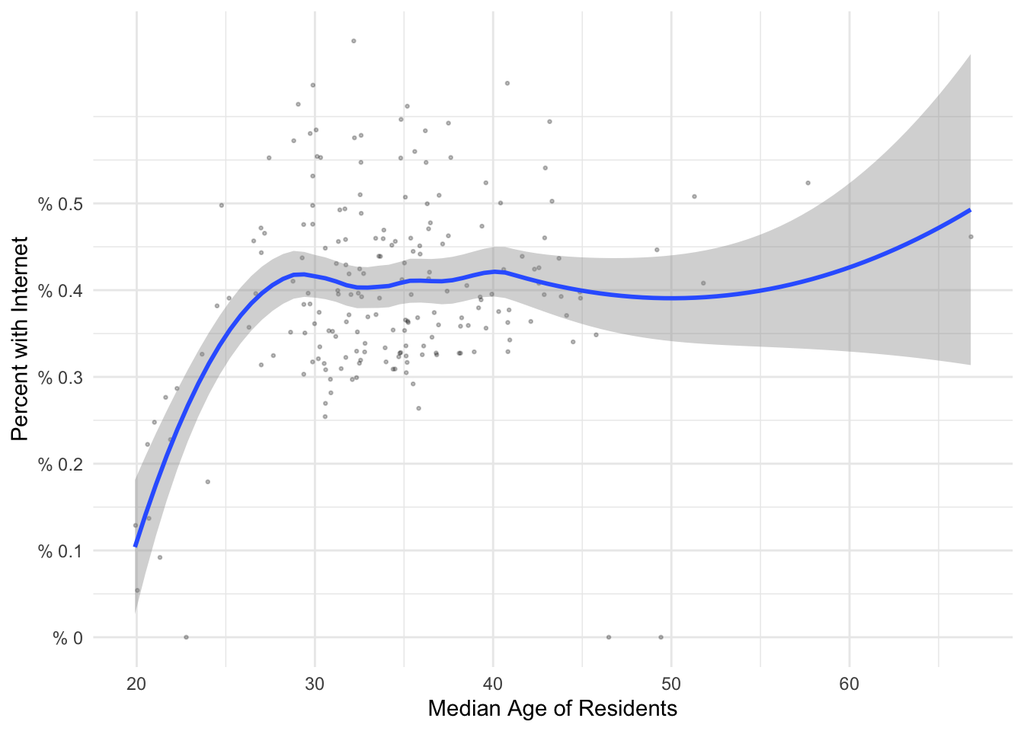

```r
ggplot(MA_tracts, aes(x = med_ageE, y = internet_acc)) +
  geom_point(size = 0.5, alpha = 0.25, position = "jitter") +
  geom_smooth() +
  theme_minimal() +
  scale_x_continuous(name = "Median Age of Residents") +
  scale_y_continuous(name = "Percent with Internet",
                     breaks = seq(0, .5, by = .1),
                     labels = paste("%",
                                    prettyNum(seq(0, .5, by = .1),
                                              big.mark = ",")))
```

This is interesting and actually makes a lot of sense when viewed as a graph. It seems that there’s a definite upward trend in gaining internet access between ages 20-30, but then it generally stays around the same. Logically, that does make sense; I can imagine that people moving out of their parents’ houses and gaining employment may affect this huge bump in the early to mid 20’s.

## Relationship #2, two categorical variables

```r
chi_sq <- chisq.test(MA_tracts$maj_race, MA_tracts$large_foreign == "TRUE")
chi_sq
```

```
##
##  Pearson's Chi-squared test
##
## data:  MA_tracts$maj_race and MA_tracts$large_foreign == "TRUE"
## X-squared = 42.04, df = 4, p-value = 1.637e-08
```

```r
chi_sq$observed
```

```
##
## MA_tracts$maj_race FALSE TRUE
##        asian           0    1
##        black           5   26
##        latino          0   15
##        no_majority    13   37
##        white          62   38
```

```r
chi_sq$expected
```

```
##
## MA_tracts$maj_race      FALSE       TRUE
##        asian        0.4060914  0.5939086
##        black       12.5888325 18.4111675
##        latino       6.0913706  8.9086294
##        no_majority 20.3045685 29.6954315
##        white       40.6091371 59.3908629
```

As seen above, the p-value is far smaller than .05. Therefore, the relationship between majority race and nativity is significant.

## Relationship #3, categorical variable (3 or more levels) + continuous variables

```r
anova <- aov (med_ageE ~ maj_race, data = MA_tracts)
summary(anova)
```

```
##              Df Sum Sq Mean Sq F value Pr(>F)
## maj_race      4    181   45.26   1.042  0.387
## Residuals   192   8337   43.42
## 7 observations deleted due to missingness
```

```r
anova <- aov (internet_acc ~ maj_race, data = MA_tracts)
summary(anova)
```

```
##              Df Sum Sq Mean Sq F value   Pr(>F)
## maj_race      4 0.4287 0.10718   10.13 1.84e-07 ***
## Residuals   192 2.0312 0.01058
## ---
## Signif. codes:  0 '***' 0.001 '**' 0.01 '*' 0.05 '.' 0.1 ' ' 1
## 7 observations deleted due to missingness
```

```r
anova <- aov (total_popE ~ maj_race, data = MA_tracts)
summary(anova)
```

```
##              Df    Sum Sq Mean Sq F value Pr(>F)
## maj_race      4  35594792 8898698   2.762 0.0288 *
## Residuals   199 641157010 3221895
## ---
## Signif. codes:  0 '***' 0.001 '**' 0.01 '*' 0.05 '.' 0.1 ' ' 1
```

Difference Check:

```r
differences <- TukeyHSD(anova)

as_tibble(cbind(pair = row.names(differences$maj_race),
                differences$maj_race))
```

```
## # A tibble: 10 x 5
##    pair             diff            lwr            upr            `p adj`
##    <chr>            <chr>           <chr>          <chr>          <chr>
##  1 black-asian      -1061.29032258… -6081.8066421… 3959.22599702… 0.97761291750…
##  2 latino-asian     -1207.19999999… -6310.7056826… 3896.30568262… 0.96625722303…
##  3 no_majority-asi… -2234.78947368… -7219.3951743… 2749.81622697… 0.73135895389…
##  4 white-asian      -1767.30999999… -6733.4039084… 3198.78390849… 0.86415267206…
##  5 latino-black     -145.909677419… -1700.1088745… 1408.28951972… 0.99901085613…
##  6 no_majority-bla… -1173.49915110… -2276.2497497… -70.748552480… 0.03072423852…
##  7 white-black      -706.019677419… -1721.8216264… 309.782271646… 0.31360009995…
##  8 no_majority-lat… -1027.58947368… -2461.5507771… 406.371829818… 0.28314287328…
##  9 white-latino     -560.110000000… -1928.3350315… 808.115031530… 0.79211156645…
## 10 white-no_majori… 467.4794736842… -352.62020030… 1287.57914767… 0.51888306995…
```

I can see that the summary from ANOVA test 1 shows me that there is not significant relationship between median age of the census tract and the majority race of the census tract. There is a significance to the relationships of both other tests, but I’m particularly interested in test 2, which shows the relationship between internet access and the majority race of each tract.

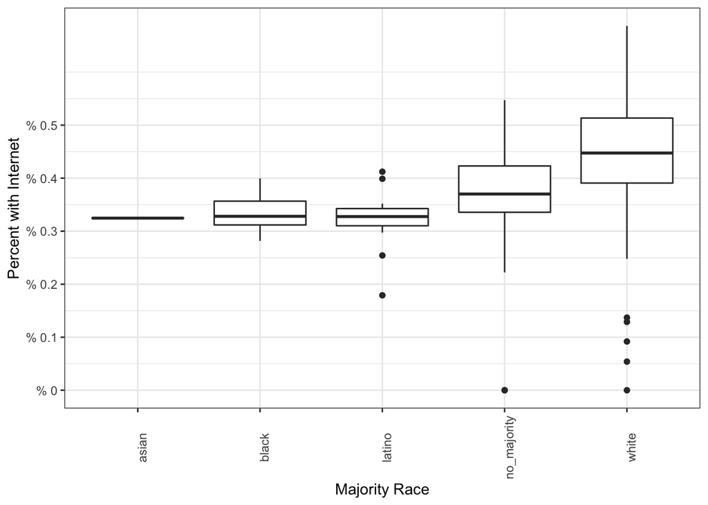

```r
ggplot(MA_tracts, aes(x = maj_race, y = internet_acc)) +
  geom_boxplot() +
  theme_bw() +
  theme(axis.text.x = element_text(angle = 90)) +
  scale_x_discrete(name = "Majority Race") +
  scale_y_continuous(name = "Percent with Internet",
                      breaks = seq(0, .5, by = .1),
                     labels = paste("%",
                                    prettyNum(seq(0, .5, by = .1),
                                              big.mark = ",")))
```

## Relationship #4, binary variable and continuous variables

```r
difference1 = t.test(med_ageE ~ large_foreign == "TRUE",
                    data = MA_tracts)
difference1
```

```
##
##  Welch Two Sample t-test
##
## data:  med_ageE by large_foreign == "TRUE"
## t = 2.0971, df = 144.98, p-value = 0.03772
## alternative hypothesis: true difference in means is not equal to 0
## 95 percent confidence interval:
##  0.1189998 4.0187566
## sample estimates:
## mean in group FALSE  mean in group TRUE
##            35.56375            33.49487
```

```r
difference2 = t.test(total_popE ~ large_foreign == "TRUE",
                    data = MA_tracts)
difference2
```

```
##
##  Welch Two Sample t-test
##
## data:  total_popE by large_foreign == "TRUE"
## t = -2.9452, df = 182.13, p-value = 0.003649
## alternative hypothesis: true difference in means is not equal to 0
## 95 percent confidence interval:
##  -1165.9082  -230.4488
## sample estimates:
## mean in group FALSE  mean in group TRUE
##            3604.463            4302.641
```

```r
difference3 = t.test(internet_acc ~ large_foreign == "TRUE",
                    data = MA_tracts)
difference3
```

```
##
##  Welch Two Sample t-test
##
## data:  internet_acc by large_foreign == "TRUE"
## t = 2.4256, df = 130, p-value = 0.01666
## alternative hypothesis: true difference in means is not equal to 0
## 95 percent confidence interval:
##  0.007655159 0.075381527
## sample estimates:
## mean in group FALSE  mean in group TRUE
##           0.4211528           0.3796344
```

All three tests have a p-value less than .05, showing that the results of each are statistically significant. However, the statistical significance of all tests are somewhat weak.

For test 1, which examines the relationship between nativity and median age, it shows that the median age of native-born residents is about 35 while the median age of foreign-born residents is 33.

For test 2, which examines the relationship between nativity and the total population of each census tract, it shows that there are higher total populations for people born in foreign countries.

For test 3, which examines the relationship between nativity and internet access, it shows that a larger percentage of people born in the US have internet than those born in another country.

I’m interested in plotting test 3:

[figure not shown]

```r
ggplot(MA_tracts, aes(x = large_foreign, y = internet_acc)) +
  geom_boxplot() +
  theme_bw() +
  scale_x_discrete(name = "Born in the US, yes or no",
                   labels = c("No", "Yes")) +
   scale_y_continuous(name = "Percent with Internet",
                    breaks = seq(0, .5, by = .1),
                     labels = paste("%",
                                    prettyNum(seq(0, .5, by = .1),
                                              big.mark = ",")))
```